# Analysis workflow in lme4 R Package

Prepared by: Rainfed Breeding Team

23 November, 2021

**Load the Required Libraries**

```r
> # Load the libraries
>   library(easypackages)
>   libraries("dplyr", "reshape2", "readxl", "ggpubr","stringr", "ggplot2",
+   "tidyverse","lme4", "data.table", "readr","plotly", "DT",
+   "pheatmap", "VennDiagram", "patchwork", "heatmaply",
+   "ggcorrplot", "RColorBrewer", "hrbrthemes", "tm", "proustr", "arm",
+    "gghighlight", "desplot", "gridExtra", "TeachingDemos", "scales", "ASExtras4",
+   "FactoMineR", "corrplot", "factoextra", "emmeans")
```

**This section shows the analysis of filtered phenotypic data in lme4 R package. The filtered data set was obtained after pre-processing and Quality check of data**

# 1 Phenotypic Data Analysis in lme4 R Package

- Here in this section phenotypic data analysis is performed in an open source R package called **lme4**. More on this R package can be found here [lme4 Tutorial 1](https://cran.r-project.org/web/packages/lme4/lme4.pdf), and [lme4 Tutorial 2](https://cran.r-project.org/web/packages/lme4/vignettes/lmer.pdf).
- The purpose of this section is to repeat the phenotypic data analysis in lme4 as ASReml R package is commercial package and may not available for all the users.
- Filtered data set will be used, same one used in ASReml R package to perform the analysis in lme4.
- ANOVA, variance components, BLUPS, BLUES and heritability is extracted for the results part.

## 1.1 Upload the Filtered Phenotypic Data

```r
> rm(list=ls())
> # Read the saved csv file, if working directly
>   if(exists('demo.data.filtered') && is.data.frame(get('demo.data.filtered'))){
+   demo.data.filtered=demo.data.filtered
+   }else{
+   demo.data.filtered<-read.csv(file="~/Documents/Analysis-pipeline/Outputs/Tables/demo.data.filtered.csv",
+                                header = TRUE)
+ # factor conversion if below are not in factors
+   columns<-c("Environment", "Genotype", "Rep", "Block", "Row", "Column", "Line.type")
+   demo.data.filtered[, columns]<-lapply(columns, function(x) as.factor(demo.data.filtered[[x]]))
+   demo.data.filtered$Yield<-as.numeric(demo.data.filtered$Yield)
+   demo.data.filtered$HT<-as.numeric(demo.data.filtered$HT)
+   demo.data.filtered$DTF<-as.numeric(demo.data.filtered$DTF)
+   }
> # Subset the required columns
>   demo.data.filtered<-demo.data.filtered[, c("Environment", "Genotype", "Rep",
+                                              "Block", "Row", "Column", "Line.type",
+                                              "Yield", "HT", "DTF")]
> # First we will arrange the rows and columns for spatial analysis.
> # Now we will subset the environments and Yields for analysis
>   demo.data.filtered<-data.frame(demo.data.filtered%>% group_by(Environment)%>%arrange(Row, Column)) # arrange by row and column
>   demo.data.filtered<-data.frame(demo.data.filtered%>% arrange(Environment)) # Arrange by environment
>
> #demo.data.filtered<-demo.data.filtered[!demo.data.filtered$Environment %in% c("Env2", "Env5","Env8", "Env9"), ]
```

## 1.2 Seperate Analayis

- First let us subset the data for on environment to show how to perform the analysis for one trial or environment in lme4 R package
- We will run models which are feasible in lme4 R package. Note spatial models are not possible to run in lme4 R package.
- We will use basic models and show how to extract the results

### 1.2.1 Subset the Data

- Subset the data for one environment first.

```r
> # Subset the environment 1
> sub.data<-subset(demo.data.filtered, Environment=="Env1")
> sub.data<-droplevels.data.frame(sub.data)
```

### 1.2.2 Run the models

**Model 1.lme4**

- The model described below is equivalent to *model 1* described in ASReml R package analysis.

$$y_{ijk}= \mu+g_{i} + r_{j}+ b_{jk} + \epsilon_{ijk}\\
y_{ijk}= \text{ is the effect of $i$th genotype in $j$th replication and $k$th block within the $j$th replication} \\
\mu= \text {overall mean}\\
g_{i}=\text{random effect of the $i$th genotype}\\
r_{j}=\text{fixed effect of the $j$th replication}\\
b_{jk}= \text {random effect of $k$th block nested within $j$ replication}\\
\varepsilon_{ijk}=\text{residual error}\\
\text{here we assume errors are independent and identically distributed }\epsilon\sim \text{$iid$N}(0,\sigma_\epsilon^2)\\$$

```r
> # Now apply model
>   model1<-lmer(Yield~Rep+(1|Genotype)+ (1|Rep:Block), data =sub.data)
```

### 1.2.3 Results

- Here we will summarize the results using *summary()* function. The first few lines of output indicate that the model was fitted by REML as well as the value of the REML criterion. The second piece of the summary output provides information regarding the random-effects and residual variation. The third piece of the summary output provides information regarding the fixed-effects and the fourth piece of summary output provides information regarding the correlation of fixed effects.

```r
> # Summarise the results
>   summary(model1)
Linear mixed model fit by REML ['lmerMod']
Formula: Yield ~ Rep + (1 | Genotype) + (1 | Rep:Block)
   Data: sub.data

REML criterion at convergence: 6239.3

Scaled residuals:
     Min       1Q   Median       3Q      Max
-1.90048 -0.59387  0.03899  0.60311  1.71001

Random effects:
 Groups    Name        Variance Std.Dev.
 Genotype  (Intercept) 431863   657.2
 Rep:Block (Intercept)  28499   168.8
 Residual              193254   439.6
Number of obs: 394, groups:  Genotype, 197; Rep:Block, 10

Fixed effects:
            Estimate Std. Error t value
(Intercept)  5233.19      94.20  55.552
Rep2           60.38     115.60   0.522

Correlation of Fixed Effects:
     (Intr)
Rep2 -0.614
```

#### 1.2.3.1 Extract variance components

- Here we will extract variance components

```r
>   Ve<- VarCorr(model1)
>   Ve
 Groups    Name        Std.Dev.
 Genotype  (Intercept) 657.16
 Rep:Block (Intercept) 168.82
 Residual              439.61
```

#### 1.2.3.2 Plot the residual vs fitted plot

- Here will show how to check for check for homoscedasticicty

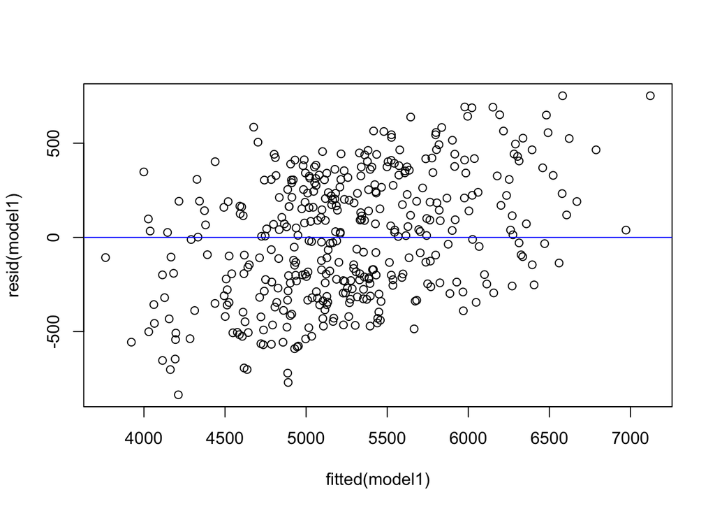

```r
> # Plot the residual plot
>   plot(fitted(model1), resid(model1), type="pearson")
>   abline(0,0, col="blue")
```

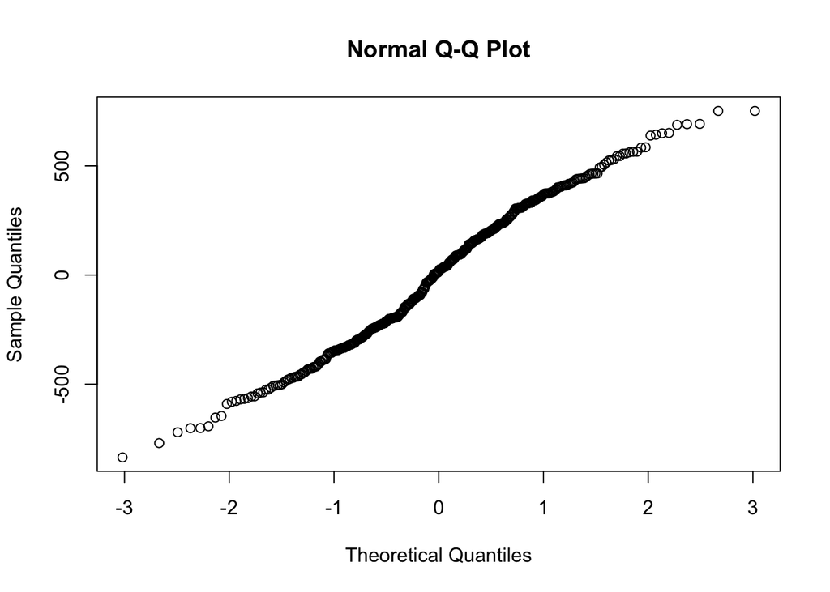

```r
> # Plot QQ plot
>   qqnorm(resid(model1))
```

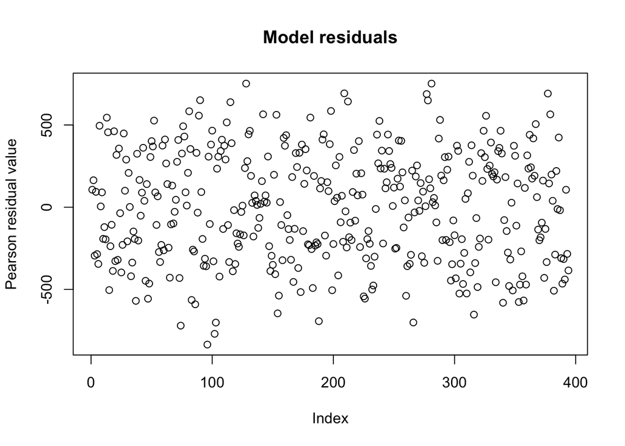

```r
> # Residual plot
>   plot(residuals(model1,type="pearson"), main='Model residuals',
+   ylab='Pearson residual value')
```

#### 1.2.3.3 ANOVA for fixed effects

```r
> # ANOVA
>   anova(model1)
Analysis of Variance Table
    npar Sum Sq Mean Sq F value
Rep    1  52723   52723  0.2728
```

#### 1.2.3.4 Extract the Fixed effects

- Here will show how to extract the BLUEs.

```r
>   BLUEs<-fixef(model1)
>   BLUEs
(Intercept)        Rep2
 5233.18558    60.37939
```

#### 1.2.3.5 Extract the Random effects

- Here will show how to extract the BLUPs.

```r
> # Extract the Random effects
>   BLUPs<-data.frame(Blups.yield=ranef(model1)$Genotype)
>   GV<-data.frame(BLUps.GY=coef(model1)$Genotype[,1]) #Genotype values (Blups +Intercept)
```

### 1.2.4 Heritability

```r
> # Extract the variance components
>   Ve<- data.frame (VarCorr(model1))
>   Ve
        grp        var1 var2      vcov    sdcor
1  Genotype (Intercept) <NA> 431862.75 657.1627
2 Rep:Block (Intercept) <NA>  28499.28 168.8173
3  Residual        <NA> <NA> 193254.24 439.6069
> # Now calculate heritability using variance components
>   genotype.var=Ve[1,4]
>   error.var=Ve[2,4]
> # Now heritability
>   h2=genotype.var/(genotype.var+error.var)*100
>   h2
[1] 93.80938
> # Reliability
>   std.err<-se.ranef(model1)$Genotype
>   v_BLUP<- mean(std.err)
> # Heritability/Reliability
>   h2<- (1-((v_BLUP)^2/(Ve[1,4]*2)))*100
>   h2
[1] 90.55042
```

## 1.3 MET Analysis

**Model 2.lme4**

### 1.3.1 Combined ANOVA

- Here ANOVA will be generated for all the factor levels.
- Replications are nested with environments and Blocks are within Replications which are nested within environment.

```r
> # Linear model to get ANOVA
>   demo.data.filtered$Environment<-as.factor(demo.data.filtered$Environment)
>   model.anova<-lm(formula = Yield~Genotype+Environment+Genotype*Environment+Environment:Rep+ Environment:Rep:Block,
+ data=demo.data.filtered)
> # Get ANOVA
>   anova(model.anova)
Analysis of Variance Table

Response: Yield
                        Df     Sum Sq   Mean Sq   F value    Pr(>F)
Genotype               199 1185402954   5956799   14.5851 < 2.2e-16 ***
Environment              9 7105461322 789495702 1933.0651 < 2.2e-16 ***
Genotype:Environment  1779 3073244084   1727512    4.2298 < 2.2e-16 ***
Environment:Rep         10   57746059   5774606   14.1390 < 2.2e-16 ***
Environment:Rep:Block   76   57387089    755093    1.8488  1.72e-05 ***
Residuals             1890  771907223    408417
---
Signif. codes:  0 '***' 0.001 '**' 0.01 '*' 0.05 '.' 0.1 ' ' 1
```

**Significant differences are observed for all factors and genotype by environment interactions are significant**

### 1.3.2 Check for Homogeneity of Variance

- Some test can be used to check variance between pair of environments as given below:
- More on this can be found on this: [Source 1](https://www.datanovia.com/en/lessons/homogeneity-of-variance-test-in-r/), [Source 2](https://www.geeksforgeeks.org/homogeneity-of-variance-test-in-r-programming/)
- Here we will check the distribution of residuals and see how they vary as we have more than two environments. For that we will run the mixed model in lme4 and then plot the residuals

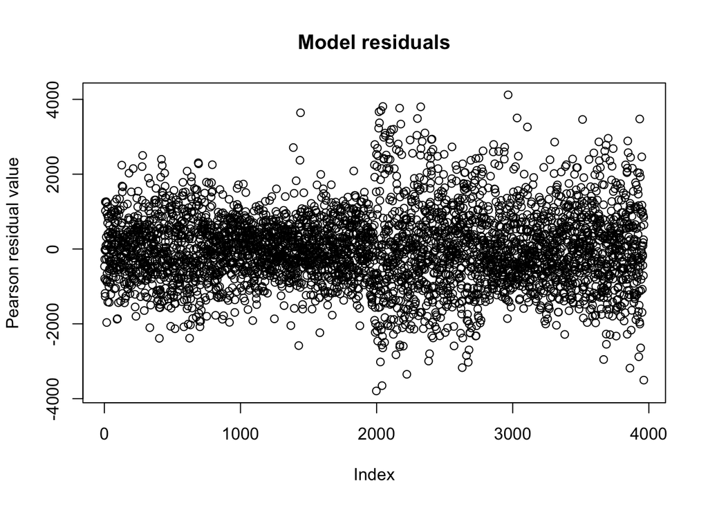

```r
> #
> model2<- lmer(Yield~Rep+(1|Genotype)+(1|Environment)+
+           (1|Environment:Rep)+(1|Environment:Rep:Block),
+           data=demo.data.filtered)
>
> #plot residuals
> plot(residuals(model2,type="pearson"), main='Model residuals',
+ ylab='Pearson residual value')
```

```r
> #var.test(Yield~Environment,data=demo.data.filtered)
```

**From the plot it is clear that residuals are not same and highly different**